### Part I

#### Solution

Tuesday, November 19, 2013

**5.** Consider the following data set

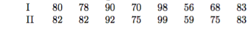

This data set is in text file `problem5. txt`. Justify your answers (if you use a computer package to do calculations, explain what you did) for full credit.

1. [7 points] Group I is a random sample of size $8$ from a section of STAT 1000 on a test and Group II is a random sample of size $8$ from a different section of STAT 1000 on the same test.
   1. Is this enough evidence to show that the 2 sections of STAT 1000 had different scores, on average? (Use $\alpha = 0.10$).  
      **Solution**  
      Two-sample *t* test. We assume the two groups are both normally distributed with the same standard deviation.  
      $H_0: \mu_1 = \mu_2$  
      $H_a: \mu_1 \neq \mu_2$  
      T.S.:

```r
# DOES NOT MATCH SOLUTIONS

raw.text <- "
80  78  90  70  98  56  68  83
82  82  92  75  99  59  75  83
"
grades.raw <- read.table(text=raw.text)
class1 <- grades.raw[1,]
class2 <- grades.raw[2,]
t.test(x=class1, y=class2, var.equal=TRUE)
```

```
##
##  Two Sample t-test
##
## data:  class1 and class2
## t = -0.47564, df = 14, p-value = 0.6417
## alternative hypothesis: true difference in means is not equal to 0
## 95 percent confidence interval:
##  -16.52768  10.52768
## sample estimates:
## mean of x mean of y
##    77.875    80.875
```

$F^*=0.2262$  
*p*-value = 0.6417.  
The *p*-value is greater than $\alpha$, so we fail to reject null hypothesis.

1. 2. Give a $90\%$ confidence interval for the difference of the means for these 2 sections.  
      **Solution**

```r
# Does not match solution
t.test(x=class1, y=class2, var.equal=TRUE, conf.level=0.90)
```

```
##
##  Two Sample t-test
##
## data:  class1 and class2
## t = -0.47564, df = 14, p-value = 0.6417
## alternative hypothesis: true difference in means is not equal to 0
## 90 percent confidence interval:
##  -14.109002   8.109002
## sample estimates:
## mean of x mean of y
##    77.875    80.875
```

I am 90% confident that the difference in the means on the test between the two groups is between -14.1 and 8.1.

2. [7 points] Now, suppose that the Statistics Department found $8$ students in 2 sections of STAT 1000 with GPAs $3.0, 3.2, 3.5, 2.8, 3.8, 2.0, 2.4,$ and $2.8$, respectively. (For example, the student who received an $80$ in section I and an $82$ in section II both have $3.0$ GPAs).
   1. Is this enough evidence to show that the 2 sections of STAT 1000 had different scores, on average? (Use $\alpha = 0.10$).  
      **Solution**  
      (A “matched pairs” scenario. It is equivalent to an experiment with a repeated observation with two tests - similar to a before/after experiment.)  
      $H_0: \mu_1 = \mu_2$  
      $H_a: \mu_1 \neq \mu_2$  
      T.S.:

```r
# Must turn data into columns
t.test(x=t(class1), y=t(class2), paired=TRUE, var.equal=TRUE, conf.level=0.90)
```

```
##
##  Paired t-test
##
## data:  t(class1) and t(class2)
## t = -3.7417, df = 7, p-value = 0.007247
## alternative hypothesis: true difference in means is not equal to 0
## 90 percent confidence interval:
##  -4.519042 -1.480958
## sample estimates:
## mean of the differences
##                      -3
```

*p*-value = 0.007. Reject null hypothesis. There is enough evidence to show that the two groups’ means differ.

2. 2. Give a $90\%$ confidence interval for the difference of the means for these 2 sections.  
      **Solution**  
      We are 90% confident that the difference between the 2 sections is between -4.5 and -1.5, making the same assumption as in part (i).
3. [8 points] Now, suppose that Group I represents the scores of $8$ randomly sampled students on the midterm in STAT 1000 and Group II represents the scores for the same students on the final exam.
   1. Is this enough evidence to show that the students’ scores on the midterm and final differ, on average? (Use $\alpha = 0.10$).  
      **Solution**  
      Paired *t* test. Same as (b)(i).
   2. Is this enough evidence to show that students who score higher on the midterm are more likely to score higher on the final?  
      **Solution**  
      Testing for positive correlation.  
      $H_0: \rho = 0$  
      $H_a: \rho > 0$

```r
# data into columns
cor.test(x=t(class1), y=t(class2), alternative="greater")
```

```
##
##  Pearson's product-moment correlation
##
## data:  t(class1) and t(class2)
## t = 15.949, df = 6, p-value = 1.929e-06
## alternative hypothesis: true correlation is greater than 0
## 95 percent confidence interval:
##  0.950499 1.000000
## sample estimates:
##       cor
## 0.9884112
```

*p*-value < 0.001. Reject $H_0$. There is enough evidence to show that the two scores are positively correlated.

4. [3 points] Looking at the results from parts (a), (b), and (c) above and noting that they all come from the same data set, do you inferences make sense? (If they are all the same and that “makes sense,” why? If they are not all the same and that “makes sense,” why?)  
   **Solution**  
   “Even though (a) and (b) have different results, it is usually the case that paired differences have lower standard deviations than two independent samples. That is the case here. So, even though the sample means are the same for groups I and II between the parts, the standard deviation is large in part a. It makes sense that there is a positive correlation between the two scores when they are paired (this is what lowers the standard deviation for the paired data, as you should have learned in your various probability courses). If they were not significantly related, we would expect similar results for parts (a) and (b). (Note, however, that significant correlation does not have to imply significant differences For example, if group I and II were exactly the same, the correlation would be 1, but the difference would be 0.)”